# 3.3: Species parameterisation for `seabream`

FAO Climate Change Risks to Fed Mariculture

Author

Tormey Reimer

Published

10 September 2026

← Previous: Parameterise species: `rainbow_trout`

Next: Parameterise species: `european_seabass` →

# Overview

These documents run the model for each target species group, and refines the raw parameters of each. The process is:

1. Load the initial (raw) bioenergetic parameters from `data/raw_data/parameters_species.xlsx`.
2. Load a typical diet for the species from `data/raw_data/feed_profiles_and_composition.xlsx`.
3. Get the average 2025 temperatures across all farms assigned to this species in 02_assigning_locations.
4. Simulate growth of a single representative individual using `fish_growth()` with the “raw” parameter values.
5. Plot all output variables to confirm that the model is behaving reasonably.
6. Generate an adjustable parameter space based on the flexibility (uncertainty) of the raw parameter values and their impact on final weight (sensitivity).
7. Use Latin Hypercube Sampling to determine which combination of adjusted parameters brings the model outcome closest to the final target weight (commercial size) within the correct culture time.
8. Plot a output values from a calibrated run to make sure that the model is still giving reasonable outputs (particularly in ingestion- and growth-related outcomes).

# Species parameters

As we are only running a single representative individual, the Monte-Carlo parameters are not in use.

**Load species parameters for seabream**

```r
this_species <- "seabream"

parameters_species <- read_excel(
  file.path(rawdata_path, 'parameters_species.xlsx'),
  sheet = this_species,
  trim_ws = T,
  n_max = 28
) %>%
  clean_names() %>%
  select(used_in_script, value, flexibility)

species_params <- parameters_species %>% pull(value) %>% as.numeric()
names(species_params) <- parameters_species %>% pull(used_in_script)

species_params[["overFmean"]] <- 0.025
species_params[["overFdelta"]] <- 0.0025
```

# Environmental/feed parameters

**Load feed and ingredient data and calculate feed composition parameters**

```r
feeds_df <- read_excel(here("data", "raw_data", "feed_profiles_and_composition.xlsx"), sheet = "feed_formulations") %>%
  select(feed, ingredient, proportion) %>%
  filter(feed == "seabream-europe")

ingredients_df <- read_excel(here("data", "raw_data", "all_ingredients.xlsx"), sheet = "all_ingredients") %>%
  select(ingredient, protein, lipid, carb)

digestibility_df <- read_excel(here("data", "raw_data", "all_ingredients.xlsx"), sheet = "all_ingredients") %>%
  clean_names() %>%
  rename(
    protein_digestibility = mean_protein_digestibility,
    lipid_digestibility = mean_lipid_digestibility,
    carb_digestibility = mean_carb_digestibility
  ) %>%
  select(ingredient, protein_digestibility, lipid_digestibility, carb_digestibility)

feed_params <- sum_feeds(
  format_feeds(feeds_df, ingredients_df, digestibility_df)
  )[[1]]
```

**Show feed nutritional profile**

```r
tibble(
  Macronutrient = c("Protein", "Lipid", "Carbohydrate"),
  Proportion = c(feed_params[["protein"]]$macro, feed_params[["lipid"]]$macro, feed_params[["carb"]]$macro),
  Digestibility = c(feed_params[["protein"]]$digestibility, feed_params[["lipid"]]$digestibility, feed_params[["carb"]]$digestibility)
) |>
  gt() |>
  fmt_percent(columns = c(Proportion, Digestibility), decimals = 1)
```

Table 1: Nutritional profile of the feed for this species.

| Macronutrient | Proportion | Digestibility |
| --- | --- | --- |
| Protein | 53.0% | 88.1% |
| Lipid | 19.2% | 95.4% |
| Carbohydrate | 20.7% | 82.8% |

The temperature timeseries used is based on the mean current temperatures at farms assigned to this model group in 02_assigning_locations.

**Define simulation times and temperature timeseries**

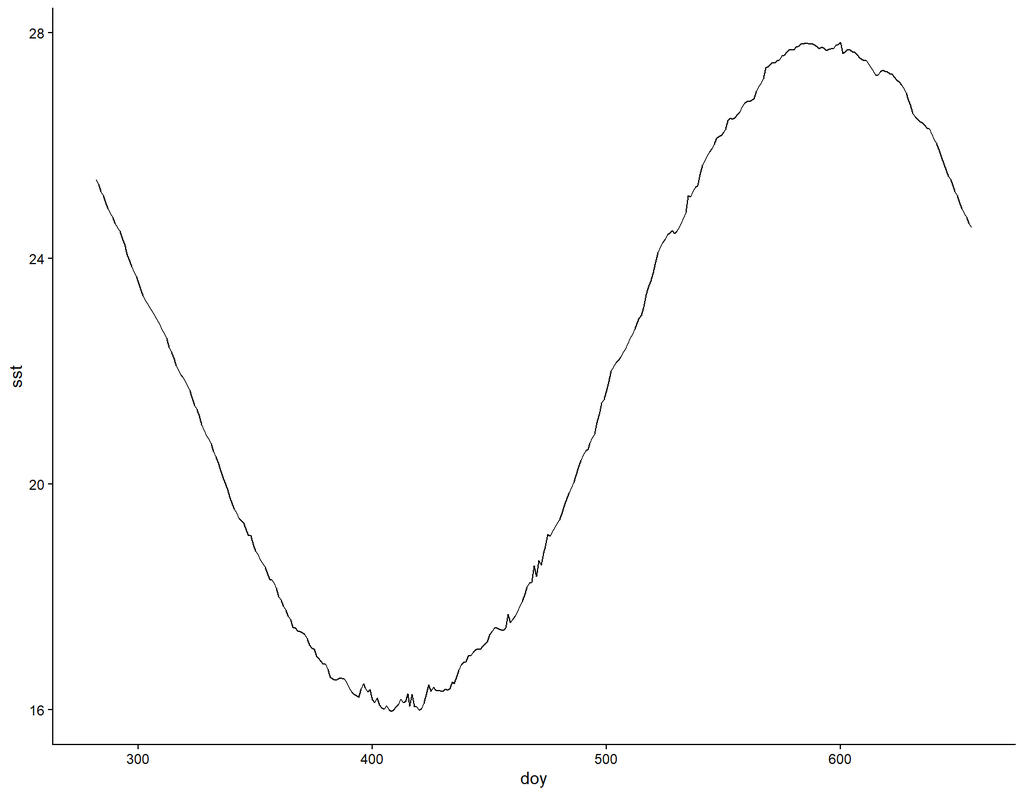

```r
# Get current mean temperatures for farms assigned to this model
farm_temps_all <- file.path(prepdata_path, "farm_temps_bymodel", "meanyear_farm_temps_seabream.qs") %>%
  qs_read() %>%
  group_by(model_name, doy) %>%
  reframe(sst = mean(sst))

farm_temps_all <- rbind(
  farm_temps_all,
  farm_temps_all %>% mutate(doy = doy + 365),
  farm_temps_all %>% mutate(doy = doy + 730)
)

# Get feeding response at each DOY
farm_temps_all$fr <- sapply(
    X = farm_temps_all$sst,
    FUN = feeding_rate,
    species_params = species_params
  )
farm_temps_all$fr[is.na(farm_temps_all$fr)] <- 0

# Get a good growing window
grow_days <- species_params[["gd"]] %>% as.integer()
gds <- farm_temps_all %>%
  mutate(
    roll_fr = slide_dbl(fr, sum, .before = 0, .after = grow_days - 1)
  ) %>%
  slice(1:(nrow(farm_temps_all) - grow_days + 1)) %>%
  slice_max(roll_fr, n = 1) %>%
  mutate(end_doy = doy + grow_days - 1)

times <- c(
  t_start = gds$doy[1],
  t_end   = gds$end_doy[1],
  dt      = 1L
)

farm_temps <- farm_temps_all %>%
  filter(doy >= times['t_start'] & doy <= times['t_end'])

ggplot(farm_temps, aes(x = doy, y = sst)) +
  geom_line() +
  theme_classic()
```

# Run model with raw parameters

**Check that all parameters being passed to the model functions are correct**

```r
check_fish_growth_inputs(
  species_params = species_params,
  water_temp     = farm_temps$sst,
  feed_params    = feed_params,
  times          = c(
    "t_start" = min(farm_temps$doy),
    "t_end" = max(farm_temps$doy),
    "dt" = 1
  ),
  init_weight    = species_params['meanW'],
  ingmax         = species_params['meanImax']
)
```

```
All inputs look good — `fish_growth()` should run without errors.
```

**Run fish_growth() for a representative individual**

```r
set.seed(42)
one_fish <- fish_growth(
  species_params = species_params,
  water_temp     = farm_temps$sst,
  feed_params    = feed_params,
  times          = c(
    "t_start" = min(farm_temps$doy),
    "t_end" = max(farm_temps$doy),
    "dt" = 1
  ),
  init_weight    = species_params['meanW'],
  ingmax         = species_params['meanImax']
)

cat(sprintf(
  'Initial weight: %.1f g  |  Final weight: %.1f g (%.1f g)  |  FCR (feed/gain): %.2f |  FCE (gain/feed): %.2f \n',
  one_fish[1, 'weight'],
  tail(one_fish[, 'weight'], 1), species_params['CS'],
  sum(one_fish[, 'food_prov'], na.rm = T) / (tail(one_fish[, 'weight'], 1) - one_fish[1, 'weight']),
  (tail(one_fish[, 'weight'], 1) - one_fish[1, 'weight']) / sum(one_fish[, 'food_prov'], na.rm = T)
))
```

```
Initial weight: 3.5 g  |  Final weight: 381.5 g (400.0 g)  |  FCR (feed/gain): 1.34 |  FCE (gain/feed): 0.75
```

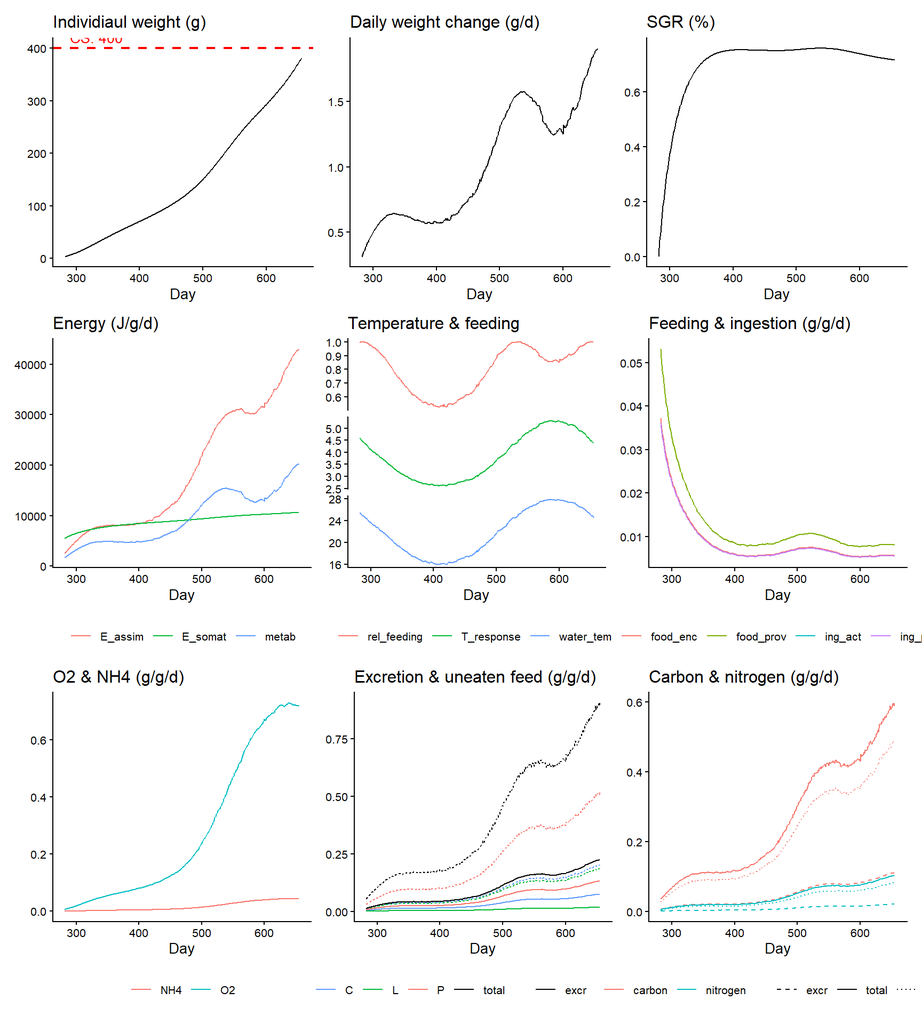

Figure 1: All fish_growth() output variables for a representative individual over a single grow-out period using the default temperature timeseries and feed composition.

# Model sensitivity

**Set uncertainty of parameters (and remove parameters not being tested for sensitivity)**

```r
# "flexibility" refers to the flexibility I'm willing to give each parameter (ie uncertainty)
flex_params <- parameters_species %>%
  select(param = used_in_script, flexibility) %>%
  filter(!is.na(flexibility)) %>%
  arrange(flexibility)
```

**Calculate parameter sensitivity for weight and SGR across plus-minus 10 percent parameter perturbations**

```r
species_params_sens <- map(
  flex_params$param,
  function(nm) {
    map(c(0.9, 1.0, 1.1), function(level) {
      species_params[nm] <- species_params[nm] * level
      species_params
    }) %>%
      setNames(c("low", "med", "high"))
  }
) %>%
  setNames(flex_params$param)

set.seed(42)
sens_results <- map2_dfr(
  species_params_sens,
  names(species_params_sens),
  function(sp, nm) {
    map_dfr(sp, function(sp_lev) {
      fish_growth(
        species_params = sp_lev,
        water_temp     = farm_temps$sst,
        feed_params    = feed_params,
        times          = c(
          "t_start" = min(farm_temps$doy),
          "t_end" = max(farm_temps$doy),
          "dt" = 1
        ),
        init_weight    = sp_lev['meanW'],
        ingmax         = sp_lev['meanImax']
      ) %>%
        as.data.frame() %>%
        tail(1) %>%
        select(weight, SGR)
    }) %>%
      mutate(
        param = nm,
        level = names(sp)
      )
  }
)

# Calculate sensitivity
sens_results <- sens_results %>%
  group_by(param) %>%
  summarise(across(c(weight, SGR), ~ (.x[level == "high"] - .x[level == "low"]) / (.x[level == "med"] * 0.2), .names = "{.col}")) %>%
  pivot_longer(
    cols = !contains("param"),
    values_to = "sens", names_to = "output",
    names_transform = c(output = as.factor)
  ) %>%
  left_join(flex_params, by = "param") %>%
  mutate(param = factor(param, levels = rev(flex_params$param)))
```

Figure 2 shows how sensitive the model output (individual weight/SGR) is to changes in each parameter - ie the positive/negative impact of increasing that parameter by 10%.

**Plot parameter sensitivity as a barplot facetted by output variable**

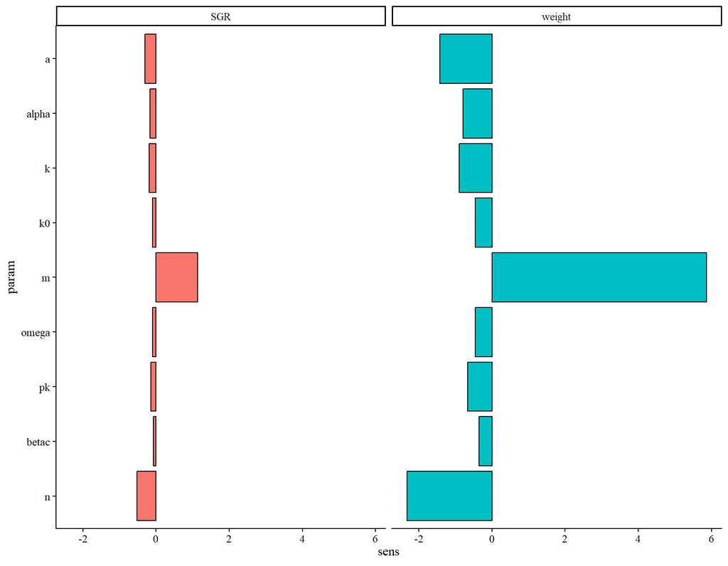

Figure 2: Sensitivity of final weight and SGR to ±10% perturbations of each model parameter. Values represent the proportional change in output per unit change in parameter.

```r
sens_results %>%
  ggplot(aes(x = param, y = sens, fill = output)) +
  geom_col(colour = "black") +
  coord_flip() +
  facet_wrap(~output) +
  prettyplot()
```

# Hypercube adjustment

The hypercube adjustment uses Latin Hypercube Sampling (LHS) to search for parameter combinations that bring model output closer to the target weight (commercial size). Sampling ranges for each parameter are set inversely proportional to both its sensitivity (from Section 5) and its flexibility rank. Therefore, parameters that have a disproportionately large effect on individual weight or that we are less willing to change are given narrower sampling ranges (Figure 3). The flexibility rank is set manually (subjectively) based on how confident I am with the raw values provided.

These values are not allowed to change:

- Minimum, maximum and optimum temperature parameters. These are likely to be a majore factor affecting growth, but they are also some of the easiest parameters to find in the literature.
- Commercial size and the length of the culture period.

As for the rest of parameter values, they are generally allowed to change.

- Parameters taken from defaults or other species are the most flexible, as they’re really just “placeholder” values.
- The derived parameters relating to internal model workings (e.g. alpha, m, n, and betac) are moderately flexible, as they are more a “means to an end” than important in and of themselves.
- Parameters that are data-driven and measurable (e.g. meanW, meanImax) are less flexible, but still changeable.
- All parameters are restricted to changes +-10% of their default value, to prevent wild adjustments.

**Calculate per-parameter sampling ranges from sensitivity and flexibility**

```r
# Combine sensitivity across both output variables (mean absolute sensitivity)
sens_combined <- sens_results %>%
  group_by(param, flexibility) %>%
  summarise(mean_abs_sens = mean(abs(sens)), .groups = "drop")

# Range score: inversely proportional to mean absolute sensitivity and flexibility rank.
# Cap 1/sens to avoid blow-up when sensitivity is near zero.
max_inv_sens <- 20
min_inv_sens <- 0.1
sens_combined <- sens_combined %>%
  mutate(
    inv_sens  = pmax(min_inv_sens, pmin(1 / pmax(mean_abs_sens, 1 / max_inv_sens), max_inv_sens)),
    raw_range = inv_sens * (1 / flexibility)
  )

# Cap range changes at +-10%
sens_combined <- sens_combined %>%
  mutate(
    param        = as.character(param),
    sample_range = scales::rescale(raw_range, to = c(0.005, 0.10))
  )
```

**Plot sampling ranges per parameter**

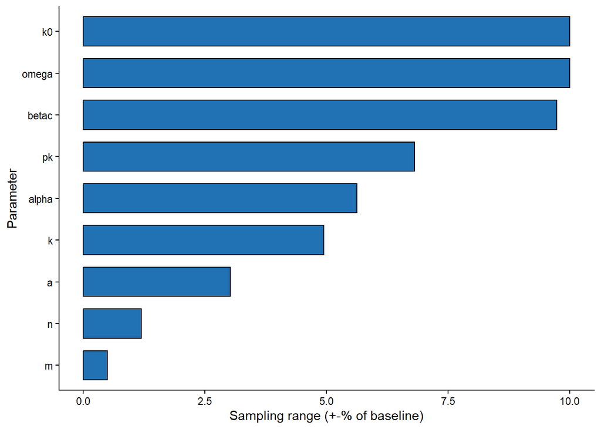

Figure 3: LHS sampling range (as a proportion of baseline value) for each parameter. Wider bars indicate parameters that are less sensitive and/or more flexible, giving the sampler more room to explore. Sampling range is capped at +-10% of baseline.

```r
sens_combined %>%
  mutate(param = factor(param, levels = param[order(sample_range)])) %>%
  ggplot(aes(x = param, y = sample_range * 100)) +
  geom_col(fill = "#2171b5", colour = "black", width = 0.7) +
  coord_flip() +
  labs(x = "Parameter", y = "Sampling range (+-% of baseline)") +
  theme_classic()
```

**Define target experimental data as a list of experiments - each with its own temperature timeseries and named target outputs**

```r
# Each entry in `target_experiments` represents one experimental condition.
# `water_temp` : data.frame with columns `day` (integer) and `temp_C` (numeric)
#                matching that experiment's temperature conditions.
# `targets`    : a named numeric vector of any model output columns to fit.
#                Different experiments can supply different (or overlapping) outputs.

# SS fitness is computed as the MEAN squared error across all (experiment × output)
# observations, so experiments with more targets do not dominate the fit.
target_experiments <- list(
  list(
    water_temp = farm_temps$sst,
    targets    = c(weight_change = unname(species_params["CS"] - species_params["meanW"])),
    meanW      = species_params["meanW"]
  )
)

n_pairs <- length(target_experiments)

# This function processes the fish_growth() output to get it ready for comparison. It's defined here so that if different comparisons are added in this chunk I can change the calculation everywhere at once
get_comparison_stats <- function(df) {
  dfdf <- as.data.frame(df)
  data.frame(
    weight_change = tail(dfdf$weight, 1) - head(dfdf$weight, 1),
    SGR = tail(dfdf$SGR, 1)
  )
}
```

```r
n_samples     <- 2500
param_names   <- sens_combined$param
sample_ranges <- sens_combined$sample_range
n_params      <- length(param_names)

set.seed(42)
lhs_raw <- randomLHS(n_samples, n_params)

# Map [0, 1] to [1 - range, 1 + range] multipliers for each parameter
multiplier_matrix <- sweep(lhs_raw * 2 - 1, 2, sample_ranges, "*") + 1
colnames(multiplier_matrix) <- param_names

# Run model once per experiment for each LHS sample.
# All final-row model output columns are retained so any named target can be used.
lhs_results <- vector("list", n_samples)
start_time  <- proc.time()["elapsed"]

for (i in seq_len(n_samples)) {
  if (i %% 500 == 0) {
    elapsed <- round(proc.time()["elapsed"] - start_time, 1)
    rate    <- i / elapsed
    eta     <- round((n_samples - i) / rate, 1)
    cat(sprintf(
      "Sample %4d / %d | elapsed: %.0fs | ETA: %.0fs\n",
      i, n_samples, elapsed, eta
    ))
  }

  sp <- species_params
  for (j in param_names) {
    sp[j] <- species_params[j] * multiplier_matrix[i, j]
  }

  # Run once per experiment; keep all output columns from the final timestep
  pair_results <- vector("list", n_pairs)
  for (k in seq_len(n_pairs)) {
    wt <- target_experiments[[k]]$water_temp

    change_params <- names(target_experiments[[k]])[names(target_experiments[[k]]) %in% names(species_params)]
    if (length(change_params) > 0) {
      for (c in change_params) {
        sp[c] <- unlist(target_experiments[[k]][c])
      }
    }

    result <- tryCatch(
      fish_growth(
        species_params = sp,
        water_temp     = wt,
        feed_params    = feed_params,
        times          = c(
          "t_start" = 1,
          "t_end"   = length(wt),
          "dt"      = 1
        ),
        init_weight = sp["meanW"],
        ingmax      = sp["meanImax"]
      ),
      error = function(e) NULL
    )
    if (!is.null(result)) {
      final <- get_comparison_stats(result)
      pair_results[[k]] <- final %>% mutate(sample = i, pair = k, .before = 1)
    }
  }

  pair_df <- bind_rows(pair_results)
  # Only retain samples where all experiments completed successfully
  if (nrow(pair_df) == n_pairs) {
    lhs_results[[i]] <- pair_df
  }
}
```

```
Sample  500 / 2500 | elapsed: 12s | ETA: 47s
Sample 1000 / 2500 | elapsed: 23s | ETA: 35s
Sample 1500 / 2500 | elapsed: 35s | ETA: 24s
Sample 2000 / 2500 | elapsed: 47s | ETA: 12s
Sample 2500 / 2500 | elapsed: 59s | ETA: 0s
```

```r
cat(sprintf(
  "Done. Total time: %.1fs\n",
  proc.time()["elapsed"] - start_time
))
```

```
Done. Total time: 58.7s
```

```r
# One row per (sample, experiment)
lhs_results_df <- bind_rows(lhs_results)
```

**Calculate absolute weight difference between modelled and target weight change for each LHS sample**

```r
target_wt_change <- target_experiments[[1]]$targets[["weight_change"]]

# Absolute difference between modelled and target weight change per sample
lhs_fit_df <- lhs_results_df %>%
  group_by(sample) %>%
  summarise(abs_diff = abs(weight_change - target_wt_change), .groups = "drop")

# Attach multipliers for inspection of top-performing samples
multipliers_df <- as.data.frame(multiplier_matrix) %>%
  mutate(sample = seq_len(n_samples))

lhs_fit_df <- lhs_fit_df %>%
  left_join(multipliers_df, by = "sample")

# Baseline: run the unadjusted model and compute absolute difference
baseline_result <- fish_growth(
  species_params = species_params,
  water_temp     = target_experiments[[1]]$water_temp,
  feed_params    = feed_params,
  times          = c(
    "t_start" = 1,
    "t_end"   = length(target_experiments[[1]]$water_temp),
    "dt"      = 1
  ),
  init_weight = species_params["meanW"],
  ingmax      = species_params["meanImax"]
)

baseline_abs_diff <- abs(get_comparison_stats(baseline_result)$weight_change - target_wt_change)

cat(sprintf(
  "Samples completed: %d / %d\n",
  n_distinct(lhs_fit_df$sample), n_samples
))
```

```
Samples completed: 2500 / 2500
```

Figure 4 shows the distribution of absolute weight differences across all samples.

**Plot distribution of absolute weight differences across all LHS samples**

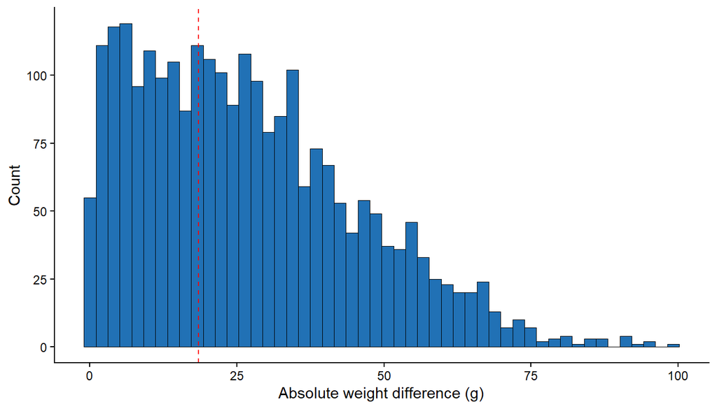

Figure 4: Distribution of absolute differences between modelled and target weight change across all LHS samples. Lower values indicate better fit to the target data. The red dashed line shows the baseline (unadjusted) absolute difference.

```r
lhs_fit_df %>%
  ggplot(aes(x = abs_diff)) +
  geom_histogram(bins = 50, fill = "#2171b5", colour = "black", linewidth = 0.2) +
  geom_vline(xintercept = baseline_abs_diff, colour = "red", linetype = "dashed") +
  labs(x = "Absolute weight difference (g)", y = "Count") +
  theme_classic()
```

The parameter multipliers for the best-fitting sample (relative to baseline) are:

**Show parameter multipliers for the best-fitting sample**

```r
best_sample <- lhs_fit_df %>%
  arrange(abs_diff) %>%
  slice_head(n = 1) %>%
  pull(sample)

best_lhs_results <- lhs_fit_df %>%
  filter(sample == best_sample) %>%
  select(all_of(param_names)) %>%
  pivot_longer(everything(), names_to = "param", values_to = "multiplier")

# If the change is extremely small (<0.05% of baseline) then the baseline version is kept
best_lhs_results <- best_lhs_results %>%
  mutate(
    multiplier    = case_when(round(multiplier, 2) == 1.00 ~ 1, T ~ multiplier),
    pct_change    = (multiplier - 1) * 100,
    baseline_val  = species_params[param],
    adjusted_val  = baseline_val * multiplier
  ) %>%
  filter(multiplier != 1) %>%
  arrange(desc(abs(pct_change)))

best_lhs_results %>%
  gt() %>%
  fmt_number(columns = c(multiplier, pct_change), decimals = 2) %>%
  fmt_number(columns = c(baseline_val, adjusted_val), decimals = 4) %>%
  cols_label(
    param        = "Parameter",
    multiplier   = "Multiplier",
    pct_change   = "% change",
    baseline_val = "Raw value",
    adjusted_val = "Calibrated value"
  )
```

Table 2: Parameter multipliers and adjusted values for the best-fitting LHS sample. Parameters are sorted by the magnitude of their percentage change from baseline.

| Parameter | Multiplier | % change | Raw value | Calibrated value |
| --- | --- | --- | --- | --- |
| betac | 1.07 | 6.97 | 0.2000 | 0.2139 |
| omega | 0.95 | −5.08 | 0.6000 | 0.5695 |
| k0 | 0.96 | −4.44 | 0.0007 | 0.0007 |
| alpha | 0.96 | −4.07 | 0.3000 | 0.2878 |
| k | 1.02 | 2.30 | 0.1390 | 0.1422 |
| n | 0.99 | −1.03 | 1.0000 | 0.9897 |

# Calibrated run

**Replace calibrated species parameters with new values**

```r
new_params <- best_lhs_results$adjusted_val
names(new_params) <- best_lhs_results$param
species_params_new <- species_params
for(nm in names(new_params)) {
  species_params_new[nm] <- new_params[nm]
}
species_params_new["gd"] <- round(species_params_new["gd"], 0)

spn <- data.frame(
  Parameter = names(species_params_new),
  Original_Value = unname(species_params),
  New_Value = unname(species_params_new),
  Pct_Change = 100*unname((species_params-species_params_new)/species_params)
)
```

**Run fish_growth() with the calibrated parameter values**

```r
# Run with the default temperature timeseries for the trajectory plot (same as
# the initial checks above), giving a single representative growth trajectory.
set.seed(42)

times <- c(
  "t_start" = gds$doy[1],
  "t_end"   = gds$doy[1] + unname(species_params_new["gd"]) - 1,
  "dt"      = 1
)

farm_temps_new <- farm_temps_all %>%
  filter(doy >= times['t_start'] & doy <= times['t_end'])

one_fish_new <- fish_growth(
  species_params = species_params_new,
  water_temp     = farm_temps_new$sst,
  feed_params    = feed_params,
  times          = times,
  init_weight    = species_params_new['meanW'],
  ingmax         = species_params_new['meanImax']
)

# Also validate against each paired experimental temperature series to confirm
# that the best parameter set improves fit across all observed conditions.
calibrated_pair_results <- map_dfr(seq_len(n_pairs), function(k) {
  wt <- target_experiments[[k]]$water_temp
  sp <- species_params_new
  if (!is.null(target_experiments[[k]]$initW)) {sp["meanW"] <- target_experiments[[k]]$initW}
  set.seed(42)
  result <- fish_growth(
    species_params = sp,
    water_temp     = wt,
    feed_params    = feed_params,
    times          = c(
      "t_start" = 1,
      "t_end"   = length(wt),
      "dt"      = 1
    ),
    init_weight = sp['meanW'],
    ingmax      = sp['meanImax']
  )
  get_comparison_stats(result) %>% mutate(pair = k)
})

# Summary comparison: calibrated vs. target per experiment
# Only columns that appear in each experiment's `targets` vector are shown.
calibrated_summary <- map_dfr(seq_len(n_pairs), function(k) {
  row  <- calibrated_pair_results %>% filter(pair == k)
  tgts <- target_experiments[[k]]$targets
  map_dfr(names(tgts), function(col) {
    data.frame(
      pair      = k,
      output    = col,
      modelled  = row[[col]],
      target    = tgts[[col]],
      diff      = row[[col]] - tgts[[col]]
    )
  })
})
```

**Display modelled vs target values for each experiment after calibration**

```r
calibrated_summary %>%
  gt() %>%
  fmt_number(columns = c(modelled, target, diff), decimals = 2) %>%
  cols_label(
    pair     = "Run",
    output   = "Output variable",
    modelled = "Modelled",
    target   = "Target",
    diff     = "Difference"
  )
```

Table 3: Comparison of calibrated model output against target values for each experiment.

| Run | Output variable | Modelled | Target | Difference |
| --- | --- | --- | --- | --- |
| 1 | weight_change | 397.79 | 396.50 | 1.29 |

Figure 5 shows all output variables over the grow-out period.

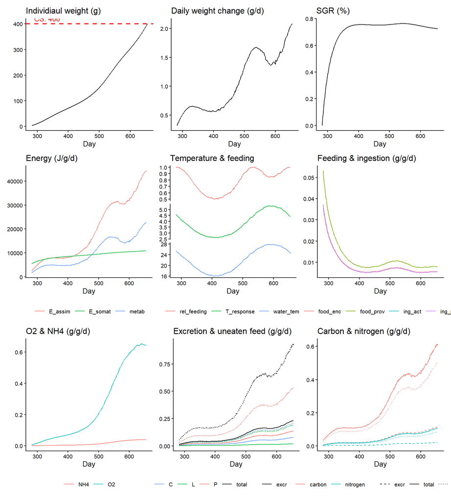

Figure 5: All fish_growth() output variables for a representative individual over a single grow-out period using the default temperature timeseries and feed composition, with the the calibrated parameter values.

**Save calibrated species parameters**

```r
qd_save(
  species_params_new,
  file.path(prepdata_path, "species_parameters", "species_parameters_seabream.qs")
)
```

← Previous: Parameterise species: `rainbow_trout`

Next: Parameterise species: `european_seabass` →

## References

Baldan, Damiano, Erika M. D. Porporato, Roberto Pastres, and Daniele Brigolin. 2018. ‘An R Package for Simulating Growth and Organic Wastage in Aquaculture Farms in Response to Environmental Conditions and Husbandry Practices’. *PLOS ONE* 13 (5): e0195732. https://doi.org/10.1371/journal.pone.0195732.